# Solution 6

HeaDS Data Lab

2024-02-26

Import necessary libraries:

```r
library(tidyverse)
library(ggplot2)
library(MASS)
```

## Getting the Dataset:

We load the data as described:

```r
data(birthwt)
?birthwt #display help page
```

Check the class

```r
class(birthwt)
```

```
## [1] "data.frame"
```

Make to tibble

```r
birthwt <- as_tibble(birthwt)
```

## Exploratory Analysis

### The Basics

- Our dataset has 189 observations and 10 variables.
- Find the description of the column in the help, i.e. `?birthwt`.

Renaming columns example. **N.B** for the subsequent analysis we use the original names, this chunk is just to show how to rename variables:

```r
colnames(birthwt) <- c("low", "age", "mother_wt", "race", "smoke", "prev_premie", "ht", "ui", "doctor_visits", "baby_wt")
```

- Check datatypes:

```r
str(birthwt)
```

```
## tibble [189 × 10] (S3: tbl_df/tbl/data.frame)
##  $ low  : int [1:189] 0 0 0 0 0 0 0 0 0 0 ...
##  $ age  : int [1:189] 19 33 20 21 18 21 22 17 29 26 ...
##  $ lwt  : int [1:189] 182 155 105 108 107 124 118 103 123 113 ...
##  $ race : int [1:189] 2 3 1 1 1 3 1 3 1 1 ...
##  $ smoke: int [1:189] 0 0 1 1 1 0 0 0 1 1 ...
##  $ ptl  : int [1:189] 0 0 0 0 0 0 0 0 0 0 ...
##  $ ht   : int [1:189] 0 0 0 0 0 0 0 0 0 0 ...
##  $ ui   : int [1:189] 1 0 0 1 1 0 0 0 0 0 ...
##  $ ftv  : int [1:189] 0 3 1 2 0 0 1 1 1 0 ...
##  $ bwt  : int [1:189] 2523 2551 2557 2594 2600 2622 2637 2637 2663 2665 ...
```

Everything is numeric but the following columns should be factors: low, race, smoke, ptl, ht, ui. We can discuss about ftv, though it has very few different values so it may make more sense to view it as categorical and you can only have discrete numbers of doctor visits.

```r
birthwt <- birthwt %>%
  mutate(low = factor(low),
         race = factor(race),
         smoke = factor(smoke),
         ptl = factor(ptl),
         ht = factor(ht),
         ui = factor(ui),
         ftv = factor(ftv))
```

- The numerical outcome variable is `bwt`, the baby’s birthweight. The categorical outcome variable is `low` which indicates whether the birthweight was low.
- The outcome is not balanced, there are many more observation of normal birthweight:

```r
birthwt %>% count(low)
```

```
## # A tibble: 2 × 2
##   low       n
##   <fct> <int>
## 1 0       130
## 2 1        59
```

- There are no missing values. There are several ways to check, i.e.

```r
# Across the whole tibble
sum(is.na(birthwt))
```

```
## [1] 0
```

```r
# Get a NA count for each variable (column)
birthwt %>% summarise(across(everything(), ~ sum(is.na(.))))
```

```
## # A tibble: 1 × 10
##     low   age   lwt  race smoke   ptl    ht    ui   ftv   bwt
##   <int> <int> <int> <int> <int> <int> <int> <int> <int> <int>
## 1     0     0     0     0     0     0     0     0     0     0
```

## Diving into the data

### Numeric variables

The numerical variables are `age` and `lwt`.

- Summary stats:

```r
birthwt %>%
  summarise(mean_age = mean(age),
            median_age = median(age),
            sd_age = sd(age),
            min_age = min(age),
            max_age = max(age),
            mean_wt = mean(lwt),
            median_wt = median(lwt),
            sd_wt = sd(lwt),
            min_wt = min(lwt),
            max_wt = max(lwt))
```

```
## # A tibble: 1 × 10
##   mean_age median_age sd_age min_age max_age mean_wt median_wt sd_wt min_wt
##      <dbl>      <int>  <dbl>   <int>   <int>   <dbl>     <int> <dbl>  <int>
## 1     23.2         23   5.30      14      45    130.       121  30.6     80
## # ℹ 1 more variable: max_wt <int>
```

```r
# or simply BUT less controlled

summary(birthwt)
```

```
##  low          age             lwt        race   smoke   ptl     ht      ui
##  0:130   Min.   :14.00   Min.   : 80.0   1:96   0:115   0:159   0:177   0:161
##  1: 59   1st Qu.:19.00   1st Qu.:110.0   2:26   1: 74   1: 24   1: 12   1: 28
##          Median :23.00   Median :121.0   3:67           2:  5
##          Mean   :23.24   Mean   :129.8                  3:  1
##          3rd Qu.:26.00   3rd Qu.:140.0
##          Max.   :45.00   Max.   :250.0
##  ftv          bwt
##  0:100   Min.   : 709
##  1: 47   1st Qu.:2414
##  2: 30   Median :2977
##  3:  7   Mean   :2945
##  4:  4   3rd Qu.:3487
##  6:  1   Max.   :4990
```

- boxplots

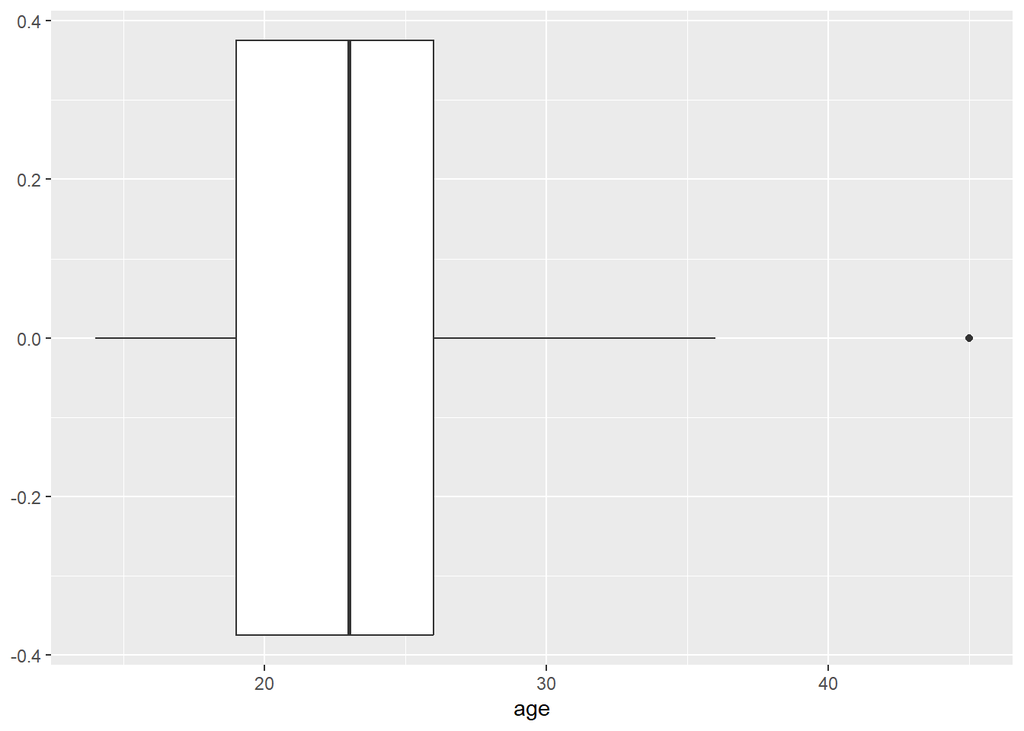

```r
ggplot(birthwt, aes(x=age)) +
  geom_boxplot()
```

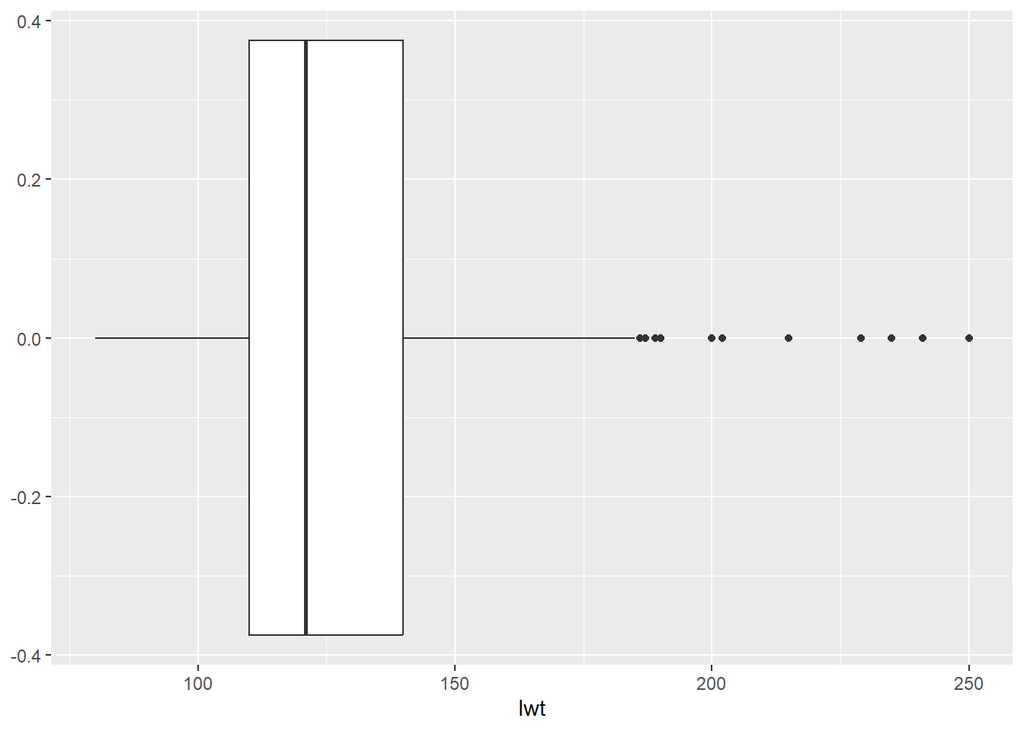

```r
ggplot(birthwt, aes(x=lwt)) +
  geom_boxplot()
```

- There appear to be many outliers in the mother’s weight
- Boxplots split up by outcome

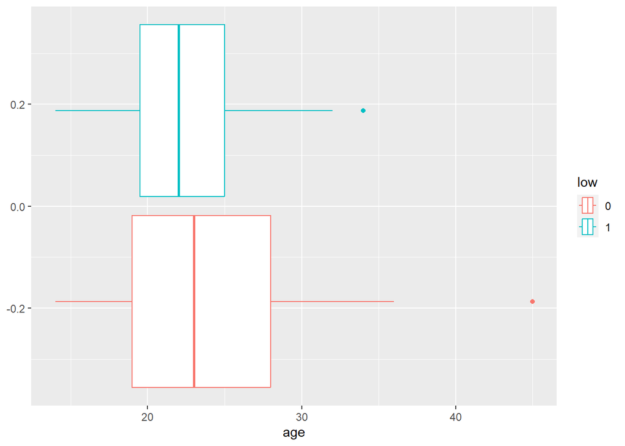

```r
ggplot(birthwt, aes(x=age, color = low)) +
  geom_boxplot()
```

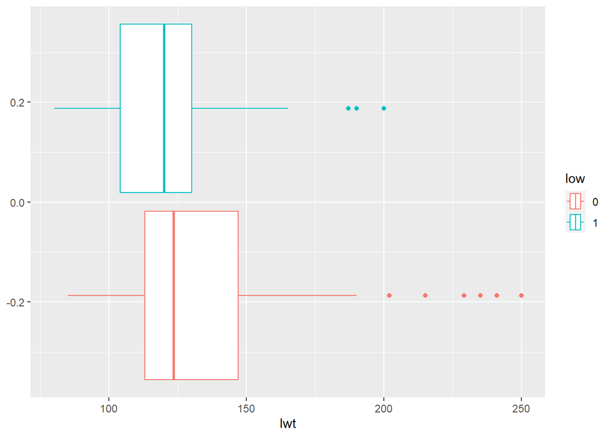

```r
ggplot(birthwt, aes(x=lwt, color = low)) +
  geom_boxplot()
```

### Categorical variables

- Barplot of smoke. Others analogous.

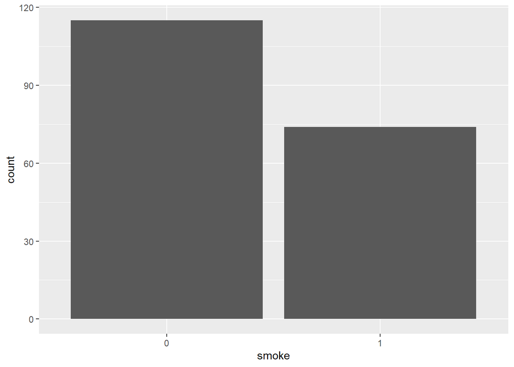

```r
ggplot(birthwt, aes(x=smoke)) +
  geom_bar()
```

- smoke by outcome

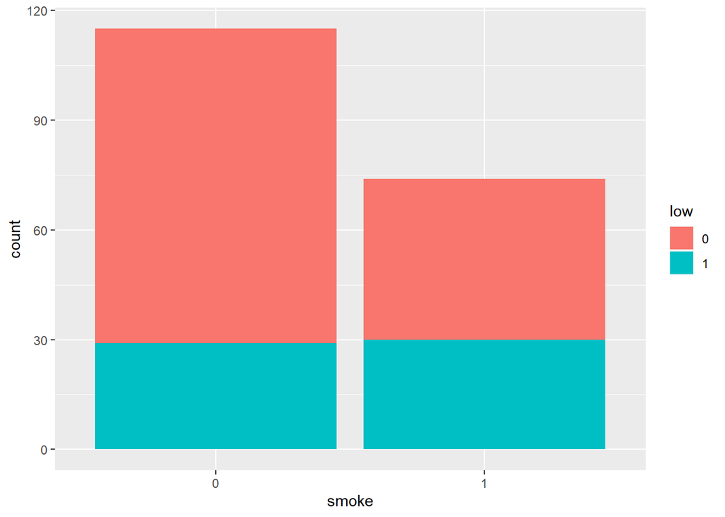

```r
ggplot(birthwt, aes(x=smoke, fill = low)) +
  geom_bar()
```

`position ='dodge'` places bars next to each other

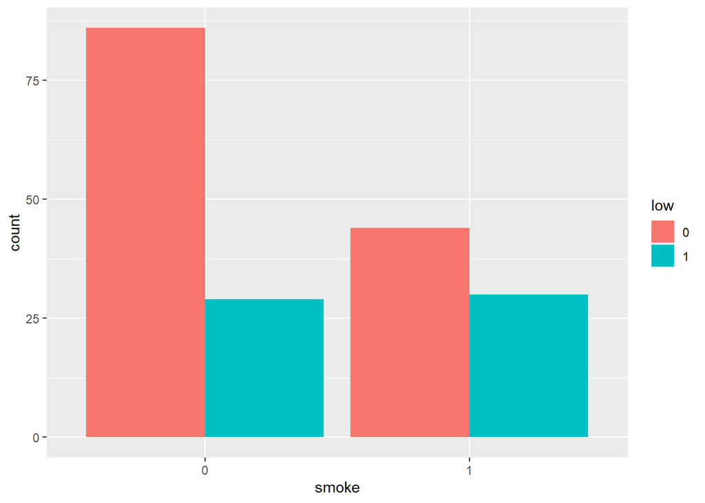

```r
ggplot(birthwt, aes(x=smoke, fill = low)) +
  geom_bar(position = 'dodge')
```

`position ='fill'` shows the relative percentage of each group

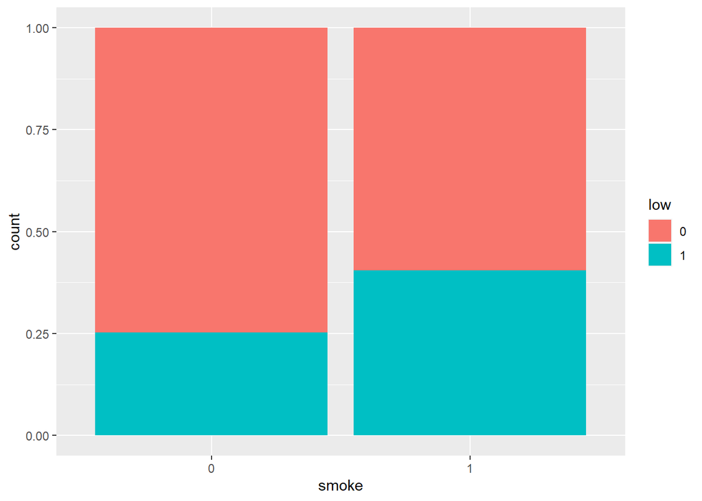

```r
ggplot(birthwt, aes(x=smoke, fill = low)) +
  geom_bar(position = 'fill')
```

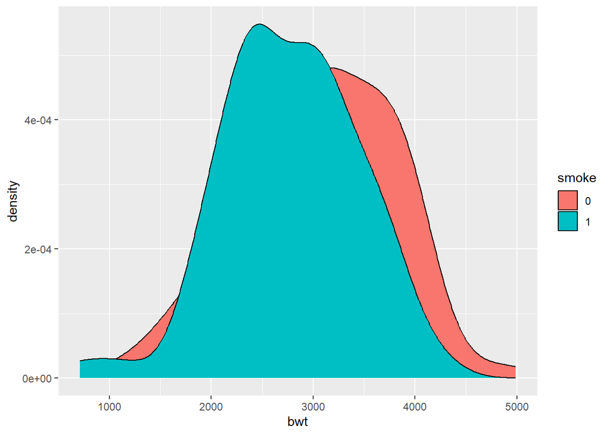

```r
ggplot(birthwt, aes(x=bwt, fill=smoke)) +
  geom_density()
```

## Subsetting the data

One example:

```r
subset <- birthwt %>%
  #may need to specify that we want dplyr's select function since we also loaded MASS
  dplyr::select(low, bwt, age, lwt, smoke, ht, ftv) %>%
  mutate(ftv=as.factor(ftv))

head(subset)
```

```
## # A tibble: 6 × 7
##   low     bwt   age   lwt smoke ht    ftv
##   <fct> <int> <int> <int> <fct> <fct> <fct>
## 1 0      2523    19   182 0     0     0
## 2 0      2551    33   155 0     0     3
## 3 0      2557    20   105 1     0     1
## 4 0      2594    21   108 1     0     2
## 5 0      2600    18   107 1     0     0
## 6 0      2622    21   124 0     0     0
```

## Modelling

### Regression Model 1

We’ll make the model on our subset:

```r
model1 <- lm(bwt ~ lwt, data = subset)
```

Inspecting the model object tells us the intercept and slope the model has estimated, as well as the model formula we have used.

```r
model1
```

```
##
## Call:
## lm(formula = bwt ~ lwt, data = subset)
##
## Coefficients:
## (Intercept)          lwt
##    2369.624        4.429
```

Plot predictor, here mother’s weight, VS outcome, baby’s weight and insert the estimates for intercept and slope we have obtained from our model.

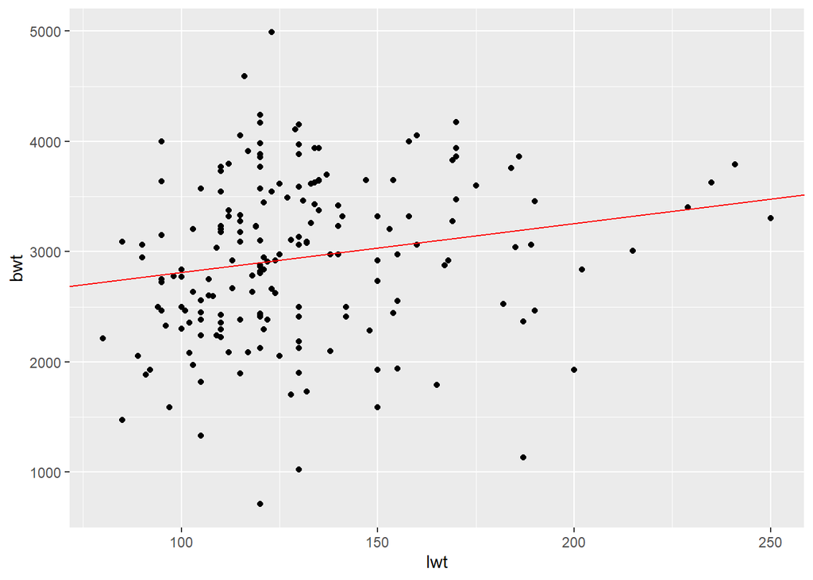

```r
ggplot(subset, aes(x = lwt, y = bwt)) +
  geom_point() +
  geom_abline(slope=4.429, intercept = 2369, color = 'red')
```

There might be a trend in the data but the error is large. See how far most data points are from the regression line.

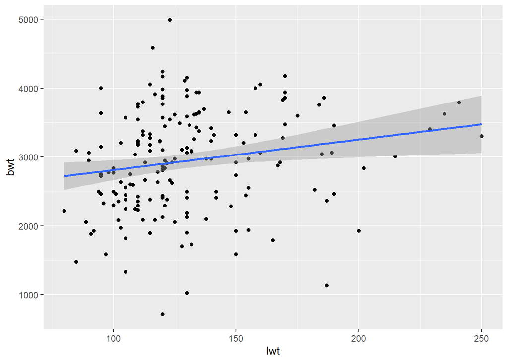

```r
ggplot(subset, aes(x = lwt, y = bwt)) +
  geom_point() +
  geom_smooth(method = 'lm')
```

The confidence interval is larger in regions with few data points (i.e. at high values of `lwt`). But even where it is relatively tight the error is still huge.

Inspect the model in more detail with `summary()`

```r
summary(model1)
```

```
##
## Call:
## lm(formula = bwt ~ lwt, data = subset)
##
## Residuals:
##      Min       1Q   Median       3Q      Max
## -2192.12  -497.97    -3.84   508.32  2075.60
##
## Coefficients:
##             Estimate Std. Error t value Pr(>|t|)
## (Intercept) 2369.624    228.493  10.371   <2e-16 ***
## lwt            4.429      1.713   2.585   0.0105 *
## ---
## Signif. codes:  0 '***' 0.001 '**' 0.01 '*' 0.05 '.' 0.1 ' ' 1
##
## Residual standard error: 718.4 on 187 degrees of freedom
## Multiple R-squared:  0.0345, Adjusted R-squared:  0.02933
## F-statistic: 6.681 on 1 and 187 DF,  p-value: 0.0105
```

### Regression Model 2

Remake the model (model2) but this time add an additional explanatory variable to the model in addition to `lwt`

```r
#Some examples
model2 <- lm(bwt ~ lwt+ht+smoke, data = subset)
model2 <- lm(bwt ~ lwt+ht, data = subset)
model2 <- lm(bwt ~ lwt+smoke, data = subset)
```

```r
summary(model2)
```

```
##
## Call:
## lm(formula = bwt ~ lwt + smoke, data = subset)
##
## Residuals:
##      Min       1Q   Median       3Q      Max
## -2030.90  -445.69    29.16   521.76  1967.76
##
## Coefficients:
##             Estimate Std. Error t value Pr(>|t|)
## (Intercept) 2501.125    230.836  10.835   <2e-16 ***
## lwt            4.237      1.690   2.507   0.0130 *
## smoke1      -272.081    105.591  -2.577   0.0107 *
## ---
## Signif. codes:  0 '***' 0.001 '**' 0.01 '*' 0.05 '.' 0.1 ' ' 1
##
## Residual standard error: 707.8 on 186 degrees of freedom
## Multiple R-squared:  0.06777,    Adjusted R-squared:  0.05775
## F-statistic: 6.761 on 2 and 186 DF,  p-value: 0.001464
```

Compare Residual standard error and Adjusted R-squared to `model1`. We see slight improvements but not very much.

95% confidence intervals for model2

```r
confint(model2)
```

```
##                    2.5 %      97.5 %
## (Intercept) 2045.7322894 2956.518425
## lwt            0.9029483    7.570523
## smoke1      -480.3918837  -63.770420
```

Predict birth weight for a mother weighing 100 lbs, and who is a smoker.

```r
newData <- data.frame(lwt=100, smoke=as.factor(1))
newData
```

```
##   lwt smoke
## 1 100     1
```

```r
predict(model2, newData)
```

```
##        1
## 2652.718
```

```r
predict(model2, newData, interval="prediction")
```

```
##        fit      lwr      upr
## 1 2652.718 1243.752 4061.684
```

### Bonus Exercise - ANOVA

Model with categorical variable as predictor.

```r
model3 <- lm(bwt ~ smoke, data = subset)
```

Now we essentially compare whether the distribution of the outcome, `bwt` differs depending on the level of smoke (0 or 1). Which is why this is a t-test.

Inspecting the model

```r
model3
```

```
##
## Call:
## lm(formula = bwt ~ smoke, data = subset)
##
## Coefficients:
## (Intercept)       smoke1
##      3055.7       -283.8
```

The coefficient of -283 means that the estimate for the mean birthweight decreases by 283 gram when smoke is 1 instead of 0.

The intercept is the mean estimate for birthweight when smoke is 0.

```r
summary(model3)
```

```
##
## Call:
## lm(formula = bwt ~ smoke, data = subset)
##
## Residuals:
##     Min      1Q  Median      3Q     Max
## -2062.9  -475.9    34.3   545.1  1934.3
##
## Coefficients:
##             Estimate Std. Error t value Pr(>|t|)
## (Intercept)  3055.70      66.93  45.653  < 2e-16 ***
## smoke1       -283.78     106.97  -2.653  0.00867 **
## ---
## Signif. codes:  0 '***' 0.001 '**' 0.01 '*' 0.05 '.' 0.1 ' ' 1
##
## Residual standard error: 717.8 on 187 degrees of freedom
## Multiple R-squared:  0.03627,    Adjusted R-squared:  0.03112
## F-statistic: 7.038 on 1 and 187 DF,  p-value: 0.008667
```

There seems to be an effect of smoke since the estimate for the coefficient is significant. The intercept is significantly different from 0 which we do not find surprising or noteworthy since babies usually weigh more than 0 gram.